# Logistic regression

Temesgen

November 19, 2017

*Read data from local folder*

```r
Stud_Alc_Cons <-read.table("D:/GitHub/IODS-project/stu_alc_consu.csv",sep = ";", header = TRUE)
colnames(Stud_Alc_Cons)
```

```
##  [1] "school"     "sex"        "age"        "address"    "famsize"
##  [6] "Pstatus"    "Medu"       "Fedu"       "Mjob"       "Fjob"
## [11] "reason"     "nursery"    "internet"   "guardian"   "traveltime"
## [16] "studytime"  "failures"   "schoolsup"  "famsup"     "paid"
## [21] "activities" "higher"     "romantic"   "famrel"     "freetime"
## [26] "goout"      "Dalc"       "Walc"       "health"     "absences"
## [31] "G1"         "G2"         "G3"         "alc_use"    "high_use"
```

The data set comprised of 382 observations of 35 variables related to the performace of students in two subjects (Mathematics and Portuguese).The data attributes contain information about students grades, demographic, and social(including alcohol consumption) activities. Details of the attributes can be obtained from https://archive.ics.uci.edu/ml/datasets/Student+Performance

*Let’s select 4 variables that have relationship with alcohol consumption and state a hypotheses for each of them*

*Selecetd variables:Grade(G2),absences,studytime,and health*

*Hypothesis(1): with high alcohol consumption, student grade decreases*

*Hypothesis(2): with high alcohol consumption rate, student absence rate increases*

*Hypothesis(3): with high alcohol consumption rate, student study less time*

*Hypothesis(4): with high alcohol consumption rate, student’s health condition deteriorates more*

*Let’s numerically and graphically explore variable distributions and relationships with alcohol consumption*

```r
library(dplyr)
```

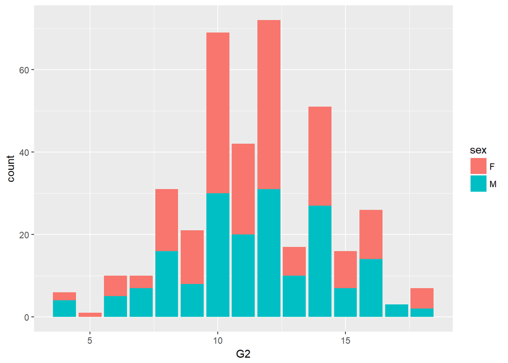

```r
library(tidyr)
library(ggplot2)
source("http://pcwww.liv.ac.uk/~william/R/crosstab.r")


g1<- ggplot(data=Stud_Alc_Cons,aes(x=G2,fill=sex))
g1+geom_bar()
```

```r
crosstab(Stud_Alc_Cons, row.vars = "G2", col.vars = "sex", type = "f")
```

```
##     sex   F   M Sum
## G2
## 4         2   4   6
## 5         1   0   1
## 6         5   5  10
## 7         3   7  10
## 8        15  16  31
## 9        13   8  21
## 10       39  30  69
## 11       22  20  42
## 12       41  31  72
## 13        7  10  17
## 14       24  27  51
## 15        9   7  16
## 16       12  14  26
## 17        0   3   3
## 18        5   2   7
## Sum     198 184 382
```

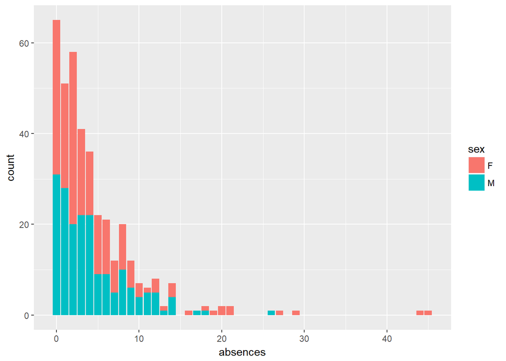

```r
g2<- ggplot(data=Stud_Alc_Cons,aes(x=absences,fill=sex))
g2+geom_bar()
```

```r
crosstab(Stud_Alc_Cons, row.vars = "absences", col.vars = "sex", type = "f")
```

```
##          sex   F   M Sum
## absences
## 0             34  31  65
## 1             23  28  51
## 2             38  20  58
## 3             19  22  41
## 4             14  22  36
## 5             13   9  22
## 6             12   9  21
## 7              7   5  12
## 8             10  10  20
## 9              6   6  12
## 10             3   4   7
## 11             1   5   6
## 12             3   5   8
## 13             1   1   2
## 14             3   4   7
## 16             1   0   1
## 17             0   1   1
## 18             1   1   2
## 19             1   0   1
## 20             2   0   2
## 21             2   0   2
## 26             0   1   1
## 27             1   0   1
## 29             1   0   1
## 44             1   0   1
## 45             1   0   1
## Sum          198 184 382
```

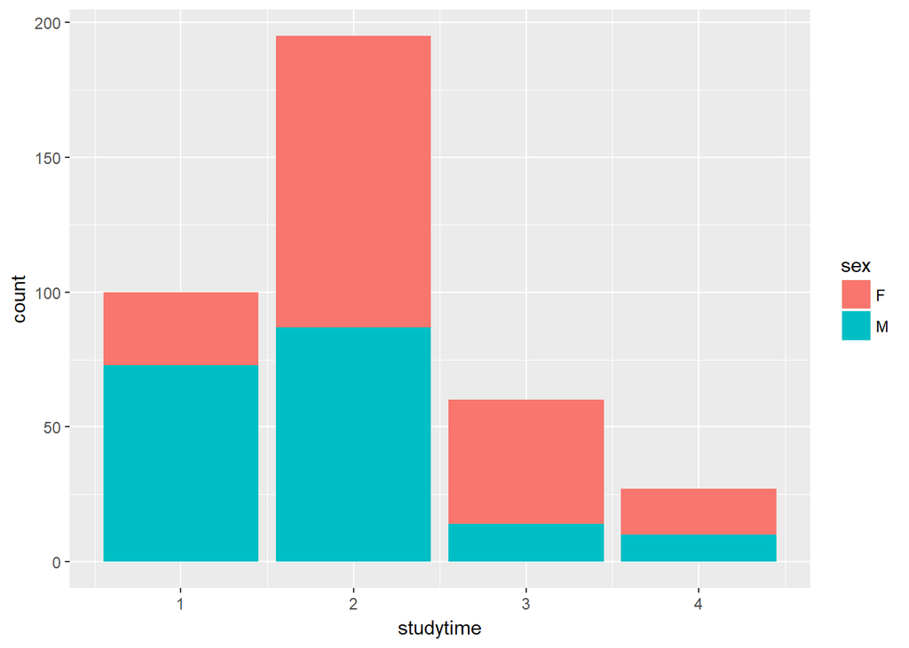

```r
g3<- ggplot(data=Stud_Alc_Cons,aes(x=studytime,fill=sex))
g3+geom_bar()
```

```r
crosstab(Stud_Alc_Cons, row.vars = "studytime", col.vars = "sex", type = "f")
```

```
##           sex   F   M Sum
## studytime
## 1              27  73 100
## 2             108  87 195
## 3              46  14  60
## 4              17  10  27
## Sum           198 184 382
```

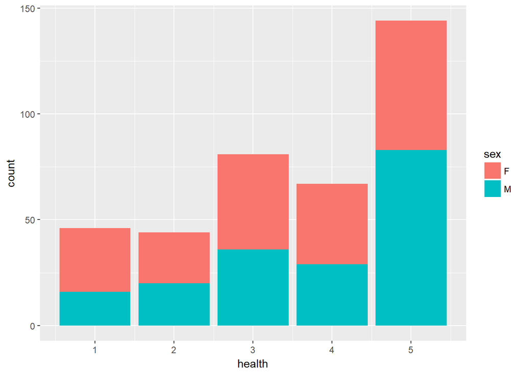

```r
g4<- ggplot(data=Stud_Alc_Cons,aes(x=health,fill=sex))
g4+geom_bar()
```

```r
crosstab(Stud_Alc_Cons, row.vars = "health", col.vars = "sex", type = "c")
```

```
##        sex      F      M
## health
## 1           15.15   8.70
## 2           12.12  10.87
## 3           22.73  19.57
## 4           19.19  15.76
## 5           30.81  45.11
## Sum        100.00 100.00
```

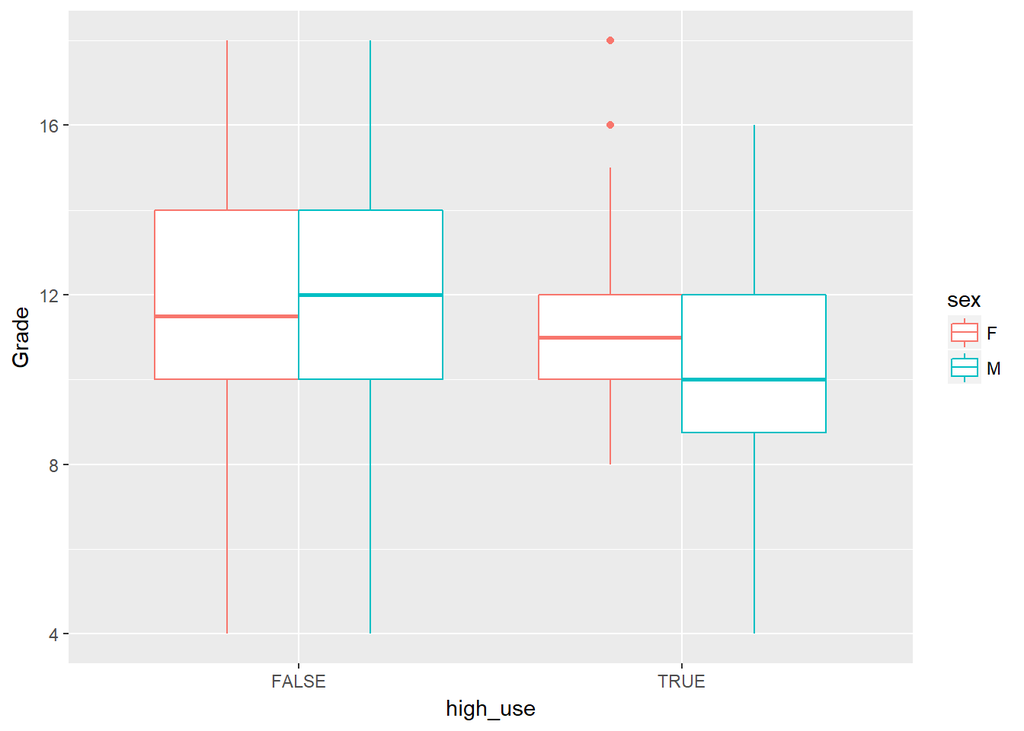

```r
g5<-ggplot(data=Stud_Alc_Cons,aes(x=high_use,y=G2,col=sex))
g5+geom_boxplot()+ylab("Grade")
```

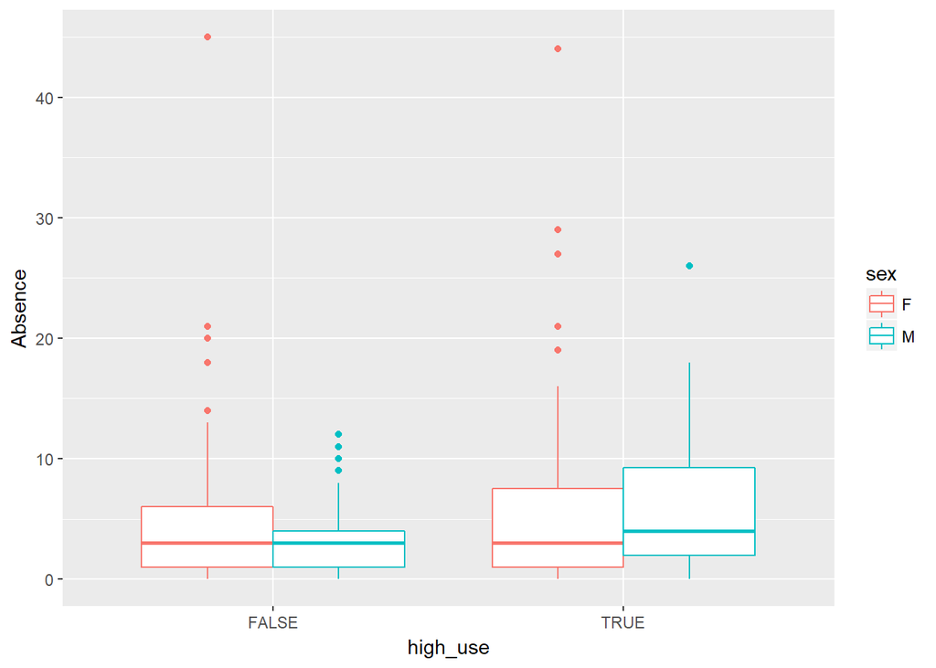

```r
g6<-ggplot(data=Stud_Alc_Cons,aes(x=high_use,y=absences,col=sex))
g6+geom_boxplot()+ylab("Absence")
```

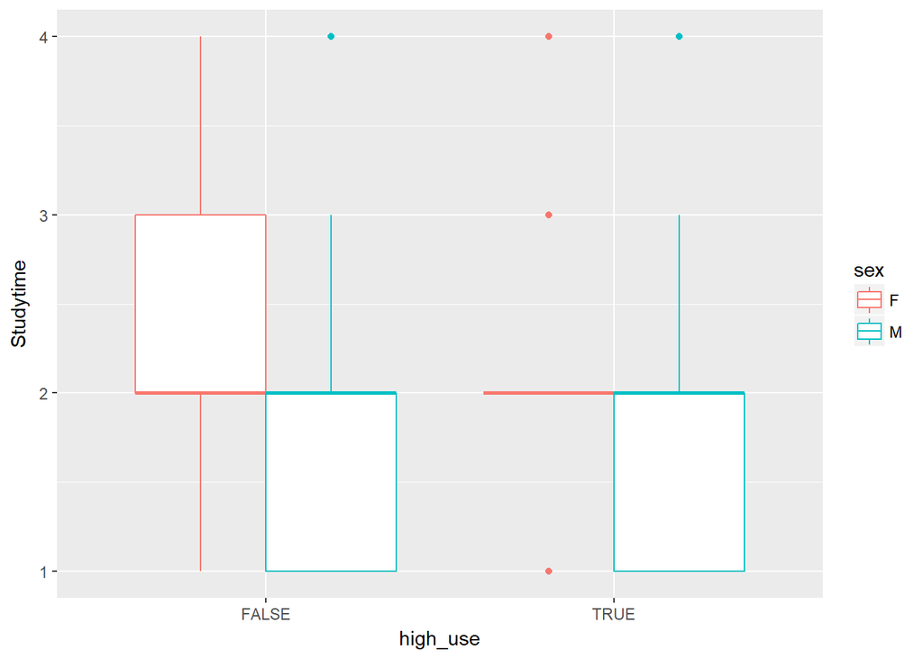

```r
g7<-ggplot(data=Stud_Alc_Cons,aes(x=high_use,y=studytime,col=sex))
g7+geom_boxplot()+ylab("Studytime")
```

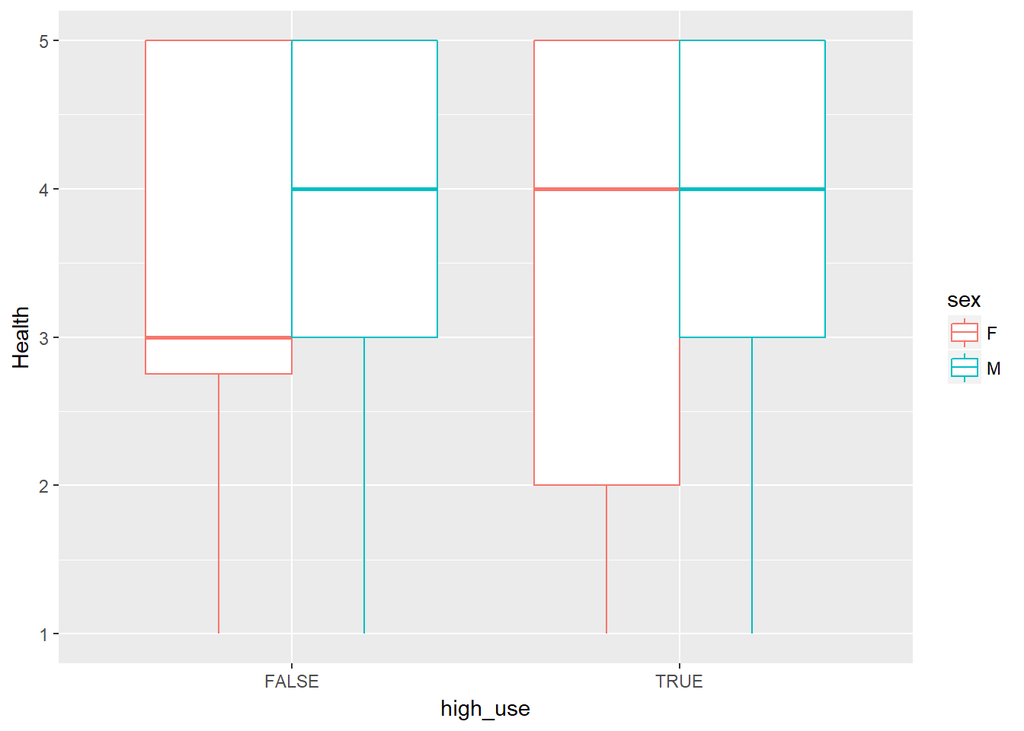

```r
g8<-ggplot(data=Stud_Alc_Cons,aes(x=high_use,y=health,col=sex))
g8+geom_boxplot()+ylab("Health")
```

*Regarding their relationship with alcohol use, the result indicates that with high alcohol use the grades for both female and male students decreases. The decline in grade is, however, more significant for male students than female. The overall result agrees well with the hypothesis stated above*

*With high rate of alcohol consumption, the number of absent male students is higher than those with low consumption. Where as for female students, the rate of alcohol consumption have no effect, i.e. the median value remain the same for both high and low consumption. Therefore the hypothesis holds true only for male students*

*The resut showed that alcohol consumption rate has no impact on the studytime for both male and female student. Thus, the hypothesis is not true*

*The result show that with high alcohol consumption, female student’s health consitions shows improvement; wheras for male students, it has no effect. Hence, the hypotheis stated above is not true based on the results obtained*

```r
m <- glm(high_use ~ G2 + absences + studytime + health , data = Stud_Alc_Cons, family = "binomial")

# print out a summary of the model
summary(m)
```

```
##
## Call:
## glm(formula = high_use ~ G2 + absences + studytime + health,
##     family = "binomial", data = Stud_Alc_Cons)
##
## Deviance Residuals:
##     Min       1Q   Median       3Q      Max
## -2.2480  -0.8409  -0.6671   1.1501   2.1433
##
## Coefficients:
##             Estimate Std. Error z value Pr(>|z|)
## (Intercept)  0.16859    0.67673   0.249 0.803263
## G2          -0.05673    0.04275  -1.327 0.184510
## absences     0.07714    0.02277   3.388 0.000705 ***
## studytime   -0.50762    0.15776  -3.218 0.001292 **
## health       0.06586    0.08565   0.769 0.441984
## ---
## Signif. codes:  0 '***' 0.001 '**' 0.01 '*' 0.05 '.' 0.1 ' ' 1
##
## (Dispersion parameter for binomial family taken to be 1)
##
##     Null deviance: 465.68  on 381  degrees of freedom
## Residual deviance: 431.02  on 377  degrees of freedom
## AIC: 441.02
##
## Number of Fisher Scoring iterations: 4
```

```r
# print out the coefficients of the model
coef(m)
```

```
## (Intercept)          G2    absences   studytime      health
##  0.16859162 -0.05672664  0.07714152 -0.50761582  0.06585520
```

```r
#print out the odd ration from coefficients of the model
ODR <- coef(m) %>% exp
ODR
```

```
## (Intercept)          G2    absences   studytime      health
##   1.1836367   0.9448523   1.0801949   0.6019290   1.0680720
```

```r
# compute confidence intervals (CI)
CI <- confint(m) %>% exp
cbind(ODR, CI)
```

```
##                   ODR     2.5 %    97.5 %
## (Intercept) 1.1836367 0.3128835 4.4745202
## G2          0.9448523 0.8683014 1.0271840
## absences    1.0801949 1.0352601 1.1321335
## studytime   0.6019290 0.4377247 0.8135916
## health      1.0680720 0.9041860 1.2660080
```

```r
#let's drop statistically insignificant variables and rebuild the model uisng absences and studytime
m1 <- glm(high_use ~  absences + studytime , data = Stud_Alc_Cons, family = "binomial")
summary(m1)
```

```
##
## Call:
## glm(formula = high_use ~ absences + studytime, family = "binomial",
##     data = Stud_Alc_Cons)
##
## Deviance Residuals:
##     Min       1Q   Median       3Q      Max
## -2.2128  -0.8387  -0.7046   1.1996   2.1832
##
## Coefficients:
##             Estimate Std. Error z value Pr(>|z|)
## (Intercept) -0.16640    0.33954  -0.490 0.624087
## absences     0.08054    0.02285   3.524 0.000425 ***
## studytime   -0.55015    0.15550  -3.538 0.000403 ***
## ---
## Signif. codes:  0 '***' 0.001 '**' 0.01 '*' 0.05 '.' 0.1 ' ' 1
##
## (Dispersion parameter for binomial family taken to be 1)
##
##     Null deviance: 465.68  on 381  degrees of freedom
## Residual deviance: 433.65  on 379  degrees of freedom
## AIC: 439.65
##
## Number of Fisher Scoring iterations: 4
```

```r
# predict the probability of high_use
probabilities <- predict(m1, type = "response")

# add the predicted probabilities to 'Stud_Alc_Cons'
Stud_Alc_Cons <- mutate(Stud_Alc_Cons, probability = probabilities)

# use the probabilities to make a prediction of high_use
Stud_Alc_Cons <- mutate(Stud_Alc_Cons, prediction = probability>0.5)

# see the last fifteen original classes, predicted probabilities, and class predictions
select(Stud_Alc_Cons, studytime,absences, high_use, probability, prediction) %>% tail(15)
```

```
##     studytime absences high_use probability prediction
## 368         2        0    FALSE   0.2198228      FALSE
## 369         2       14     TRUE   0.4652873      FALSE
## 370         2        4     TRUE   0.2799880      FALSE
## 371         1        2    FALSE   0.3645990      FALSE
## 372         2        3    FALSE   0.2640419      FALSE
## 373         1        0    FALSE   0.3281537      FALSE
## 374         1        7     TRUE   0.4618903      FALSE
## 375         3        1    FALSE   0.1497827      FALSE
## 376         1        6    FALSE   0.4419431      FALSE
## 377         3        2    FALSE   0.1603317      FALSE
## 378         2        2    FALSE   0.2486902      FALSE
## 379         2        2    FALSE   0.2486902      FALSE
## 380         2        3    FALSE   0.2640419      FALSE
## 381         1        4     TRUE   0.4026660      FALSE
## 382         1        2     TRUE   0.3645990      FALSE
```

```r
# provide 2x2 cross tabulation of the prediction and actual values
table(high_use = Stud_Alc_Cons$high_use, prediction = Stud_Alc_Cons$prediction )
```

```
##         prediction
## high_use FALSE TRUE
##    FALSE   256   12
##    TRUE     96   18
```

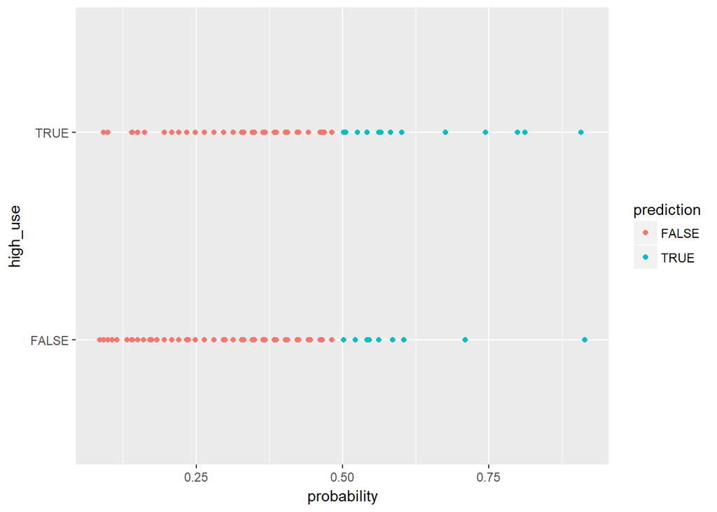

```r
# Display graphically
m <- ggplot(Stud_Alc_Cons, aes(x = probability, y=high_use, col=prediction))

# define the geom as points and draw the plot
m+geom_point()
```

```r
# calculate training error
loss_func <- function(class, prob) {
  n_wrong <- abs(class - prob) > 0.5
  mean(n_wrong)
}


loss_func(class = Stud_Alc_Cons$high_use, prob = Stud_Alc_Cons$probability)
```

```
## [1] 0.2827225
```

*The resut shows that the model error is 0.28, which means the model can commit a pediction error of about 28%*

```r
# performing 10-fold cross validation
library(boot)
cros_val <- cv.glm(data = Stud_Alc_Cons, cost = loss_func, glmfit = m1, K = 10)

# average number of wrong predictions in the cross validation
cros_val$delta[1]
```

```
## [1] 0.2853403
```

*The preiction error is 0.28. Hence, I didn’t find a better model compared to the model in the DataCamp*